# The Grammar of ggplot

R Bootcamp

Nate Hall

August 23, 2019

# Why does a plotting package have grammar?

While it may sound strange, knowing the grammar of the `ggplot2` package is fundamental to being able to understand the core of how to use the package. Grammar is generally thought of as the syntactic rules of a language that can be combined with a variety of substantive material. Grammar or syntax provide the structure of how language can be expressed. In other words, the grammar of `ggplot2` is another way of saying the *rules* of how to format a line (or lines) of code to give us a beautiful graph as the output. Importantly, other ways of creating graphics have syntax as well (including Excel and SPSS), but `ggplot` is going to be slightly different.

The important intuition in plotting with the `ggplot2` package is the concept of *layering*. That is, `ggplot2` attempts to move users away from thinking about point and click interfaces that produce one single graphic. Instead, the hope is to give users the freedom to think about different aspects of the graphics they would like to create that can give a highly customizable graphics experience. In the references below, you’ll see a link to the “R Graphics Cookbook”, which should further one’s intuition that `ggplot2` has the desirable property of allowing users to use more modular pieces of code to create beautiful plots exactly to the user’s specification.

# Layering in ggplot

We’ll work quickly through an example, which will end with the basic layers added to make this plot:

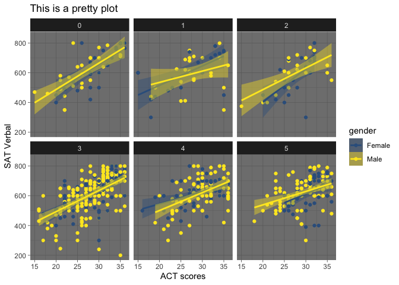

When we talk about layers in ggplot, We’re talking about creating a graphic from scratch by stacking layers on top of one another, like such:

[figure not shown]

inspired by [this website](https://skillgaze.com/2017/10/31/understanding-different-visualization-layers-of-ggplot/).

In other words, without understanding how one stacks layers in a ggplot object we will never get to the above plot. Instead we start from scratch with the raw data which looks like this:

```r
str(sat.act); head(sat.act)
```

```
## 'data.frame':    699 obs. of  6 variables:
##  $ gender   : Factor w/ 2 levels "Female","Male": 2 2 2 1 1 1 2 1 2 2 ...
##  $ education: int  3 3 3 4 2 5 5 3 4 5 ...
##  $ age      : int  19 23 20 27 33 26 30 19 23 40 ...
##  $ ACT      : int  24 35 21 26 31 28 36 22 22 35 ...
##  $ SATV     : int  500 600 480 550 600 640 610 520 400 730 ...
##  $ SATQ     : int  500 500 470 520 550 640 500 560 600 800 ...
```

```
##   gender education age ACT SATV SATQ
## 1   Male         3  19  24  500  500
## 2   Male         3  23  35  600  500
## 3   Male         3  20  21  480  470
## 4 Female         4  27  26  550  520
## 5 Female         2  33  31  600  550
## 6 Female         5  26  28  640  640
```

## Creating a base ggplot object

If we ran blindly into creating the above graph we might want to run a command that says: `plot my data please!!`

Okay, then… here we go:

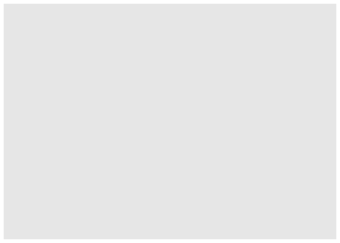

```r
gg_object <- ggplot(data = sat.act)
plot(gg_object)
```

…womp.  
What happened here is that we set up a ggplot object but have told it what to do with the data yet, it’s sitting there but R does not know how you want it so it will kick back a blank screen. We can think of this as our plotting “canvas”

Oh right, let’s run a command that says:  
`plot my data please, and this time include ACT score on the x axis and verbal SAT scores on the y axis!! Also, let's visualize males and females differently.`  
In this case, we can simply *add* aesthetic mappings to the x and y axis so the `gg_object` now knows what variables from the data.frame to plot on x and y and that males and females should be colored differently:

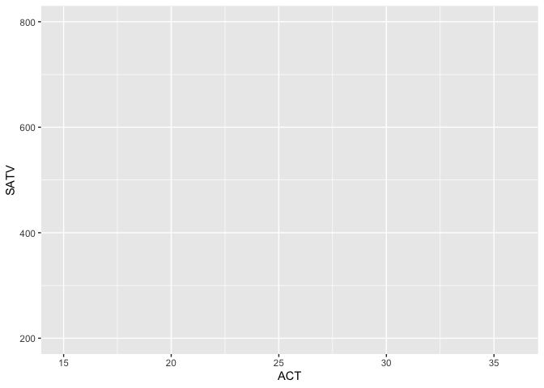

```r
gg_object_aes <- ggplot(data = sat.act, aes(x = ACT, y = SATV, color = gender, fill = gender))  #don't worry about the difference between color and fill for now
plot(gg_object_aes)
```

Now we have x and y axes specified that correspond to in the `aes()` argument. This is what many would consider the base of a ggplot object that we can now layer on top of. We still can’t see our data and in order to do so we need to add a `geom_` layer to the plot.

## Geometric layers

To actually see your data in geometric space we need to tell `ggplot` how to visualize our data. You can look on the online [documentation](https://ggplot2.tidyverse.org/reference/) for what might work best. In basic regression one of the best ways to look at the dependence of one variable on another, often a scatter plot with a regression line fit to the data.

We can pass this to R by including the `geom_point()` and `geom_smooth`command.

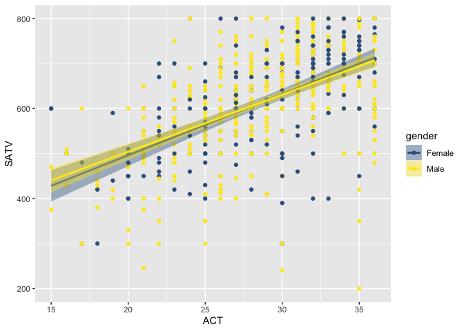

```r
gg_object_aes <- gg_object_aes + geom_point() + geom_smooth(method = lm) + scale_color_viridis_d(begin = .3, end = 1) + scale_fill_viridis_d(begin = .3) #no need to worry about the viridis calls for now
plot(gg_object_aes)
```

## Facets

The `facet_wrap()` and `facet_grid()` functions can split the data further into other panels on the basis of some variable that might be useful to visualize separately. For example, if we wanted different panels in our scatter plots to correspond to different levels of education we could add:

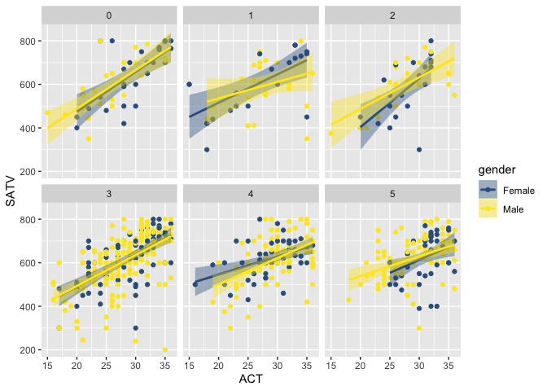

```r
gg_object_aes <- gg_object_aes + facet_wrap(~education)
plot(gg_object_aes)
```

## Themes

To add a different aesthetic touch (for example, the yellow is kindof tough to see on the white background), there are different “themes” that are built in or included in the `prettydoc` (this .Rmd) package. One that I often use is `gg_object + theme_bw()`, which is a simple black and white background with tickmarks that seem reasonable. Anyways, given the yellow on white problem,let’s plot this using a dark background.

N.B. This is not the only way to solve this problem, it is just as easy to change the colors of your data points.

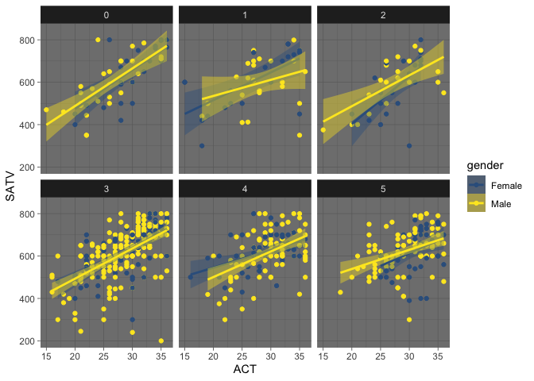

```r
gg_object_aes <- gg_object_aes+ theme_dark()
plot(gg_object_aes)
```

## Labels

We’ll finish up by changing the labels of the x and y axis and the main title using the `labs()` function.

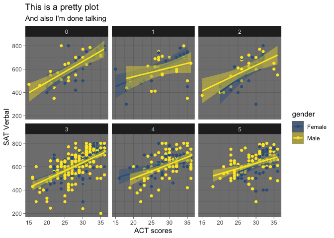

```r
gg_object_aes <- gg_object_aes + labs(x = "ACT scores", y = "SAT Verbal", title = "This is a pretty plot", subtitle =  "And also I'm done talking")
plot(gg_object_aes)
```

And we’re back to where we started, yet we’ve constructed this plot layer-by-layer and hopefully we have a bit more of an understanding for what the `ggplot2` package is capable.

To bring things full circle there is also the option to throw this all into one command from the beginning:

```r
gg_verbal_object <- ggplot(data = sat.act, aes(x = ACT, y = SATV, color = gender, fill = gender)) + geom_point() + scale_color_viridis_d(begin = .3, end = 1) + scale_fill_viridis_d(begin = .3) + geom_smooth(method = lm) + facet_wrap(~education) + theme_dark() + labs(x = "ACT scores", y = "SAT Verbal", title = "This is a pretty plot")
```

There is plenty more that I haven’t included, but here are some resources for you to consult as you embark on your journey into the soul of `ggplot`!

### Useful Resources

In order from easiest to use through the more conceptual.

[ggplot cheatsheet](https://www.rstudio.com/wp-content/uploads/2015/03/ggplot2-cheatsheet.pdf)

[R Graphics Cookbook (Chang)](http://users.metu.edu.tr/ozancan/R%20Graphics%20Cookbook.pdf)

[R for Data Science Book (Wickham)](https://r4ds.had.co.nz/data-visualisation.html)

[A Layered Grammar of Graphics (Wickham)](http://vita.had.co.nz/papers/layered-grammar.pdf)